# Notes on Data Visualisation in Seaborn & Matplotlib

#### Author: Adam Jaamour

#### 10/10/2020

https://www.kaggle.com/learn/data-visualization

```python
import matplotlib.pyplot as plt
import pandas as pd
import seaborn as sns

# Modifies the global matplotlib.units.registry dictionary. Pandas adds custom converters for pd.Timestamp, pd.Period, np.datetime64, etc.
# > Makes sure that pandas datatypes like pd.Timestamp can be used in matplotlib plots without having to cast them to another type.
pd.plotting.register_matplotlib_converters()

# Make plot outputs appear and be stored within the notebook.
%matplotlib inline
```

# Basic Plot

Load the data in:

```python
df = pd.read_csv("data/us-weather-history/KCLT.csv", index_col="date", parse_dates=True)
df = df.rename_axis("Dates", axis="rows").rename_axis("Labels", axis="columns")
df
```

| Labels Dates | actual_mean_temp | actual_min_temp | actual_max_temp | average_min_temp | average_max_temp | record_min_temp | record_max_temp | record_min_temp_year | record_max_temp_year | actual_precipitation | average_precipitation | record_precipitation |
| --- | --- | --- | --- | --- | --- | --- | --- | --- | --- | --- | --- | --- |
| 2014-07-01 | 81 | 70 | 91 | 67 | 89 | 56 | 104 | 1919 | 2012 | 0.00 | 0.10 | 5.91 |
| 2014-07-02 | 85 | 74 | 95 | 68 | 89 | 56 | 101 | 2008 | 1931 | 0.00 | 0.10 | 1.53 |
| 2014-07-03 | 82 | 71 | 93 | 68 | 89 | 56 | 99 | 2010 | 1931 | 0.14 | 0.11 | 2.50 |
| 2014-07-04 | 75 | 64 | 86 | 68 | 89 | 55 | 99 | 1933 | 1955 | 0.00 | 0.10 | 2.63 |
| 2014-07-05 | 72 | 60 | 84 | 68 | 89 | 57 | 100 | 1967 | 1954 | 0.00 | 0.10 | 1.65 |
| ... | ... | ... | ... | ... | ... | ... | ... | ... | ... | ... | ... | ... |
| 2015-06-26 | 85 | 70 | 100 | 67 | 88 | 55 | 102 | 1979 | 1952 | 1.21 | 0.11 | 1.98 |
| 2015-06-27 | 82 | 71 | 92 | 67 | 88 | 56 | 103 | 2012 | 1954 | 0.55 | 0.11 | 1.86 |
| 2015-06-28 | 76 | 66 | 85 | 67 | 88 | 53 | 101 | 1968 | 1959 | 0.00 | 0.11 | 1.83 |
| 2015-06-29 | 73 | 59 | 87 | 67 | 88 | 54 | 104 | 1974 | 2012 | 0.00 | 0.11 | 2.39 |
| 2015-06-30 | 83 | 71 | 94 | 67 | 89 | 54 | 104 | 1962 | 2012 | 0.00 | 0.11 | 2.75 |

365 rows × 12 columns

Plot all columns of the data

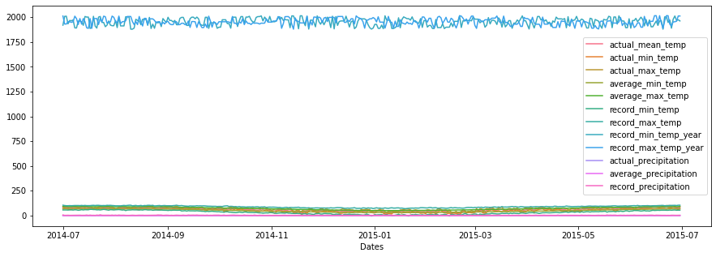

```python
plt.figure(figsize=(15,5))
sns.lineplot(data=df, dashes=False) # the standard style only supports dashes for the first 6 colours.
```

# Line Charts

```python
df = pd.read_csv("data/coronavirus-morocco/corona_morocco.csv").dropna()
df['Date'] = pd.to_datetime(df["Date"], utc=True, infer_datetime_format=True)
df = df.set_index("Date")
df.tail(5)
```

| Date | Confirmed | Deaths | Recovered | Excluded | Beni Mellal-Khenifra | Casablanca-Settat | Draa-Tafilalet | Dakhla-Oued Ed-Dahab | Fes-Meknes | Guelmim-Oued Noun | Laayoune-Sakia El Hamra | Marrakesh-Safi | Oriental | Rabat-Sale-Kenitra | Souss-Massa | Tanger-Tetouan-Al Hoceima |
| --- | --- | --- | --- | --- | --- | --- | --- | --- | --- | --- | --- | --- | --- | --- | --- | --- |
| 2020-08-22 00:00:00+00:00 | 50812.0 | 858.0 | 35040.0 | 1686164.0 | 1982.0 | 14035.0 | 1809.0 | 275.0 | 7790.0 | 224.0 | 961.0 | 8257.0 | 920.0 | 4665.0 | 808.0 | 9096.0 |
| 2020-08-23 00:00:00+00:00 | 52349.0 | 888.0 | 36343.0 | 1706521.0 | 2104.0 | 14673.0 | 1884.0 | 277.0 | 8019.0 | 235.0 | 973.0 | 8428.0 | 931.0 | 4768.0 | 884.0 | 9171.0 |
| 2020-08-24 00:00:00+00:00 | 53252.0 | 920.0 | 37478.0 | 1726728.0 | 2204.0 | 14963.0 | 1917.0 | 287.0 | 8158.0 | 234.0 | 974.0 | 8589.0 | 958.0 | 4845.0 | 915.0 | 9201.0 |
| 2020-08-25 00:00:00+00:00 | 54528.0 | 955.0 | 38293.0 | 1747642.0 | 2345.0 | 15361.0 | 2029.0 | 311.0 | 8300.0 | 235.0 | 982.0 | 8763.0 | 1004.0 | 4968.0 | 944.0 | 9287.0 |
| 2020-08-26 00:00:00+00:00 | 55864.0 | 984.0 | 40586.0 | 1768387.0 | 2453.0 | 15911.0 | 2067.0 | 325.0 | 8425.0 | 235.0 | 995.0 | 8967.0 | 1051.0 | 5084.0 | 961.0 | 9386.0 |

Use `sns.lineplot`. Can plot individual columns of the data and pass a label to tell the difference:

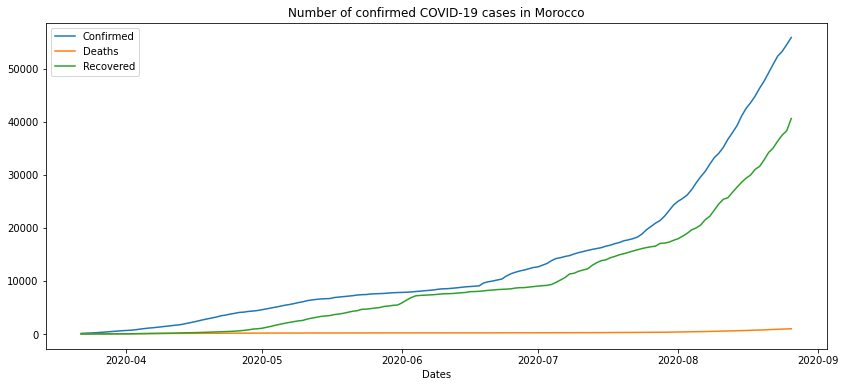

```python
# Set the width and height of the figure
plt.figure(figsize=(14,6))

# Set title
plt.title("Number of confirmed COVID-19 cases in Morocco")

sns.lineplot(data=df["Confirmed"], label="Confirmed")
sns.lineplot(data=df["Deaths"], label="Deaths")
sns.lineplot(data=df["Recovered"], label="Recovered")

# Add label for horizontal axis
plt.xlabel("Dates")
```

# Bar Charts and Heatmaps

```python
df = pd.read_csv("data/us-weather-history/KHOU.csv")
df = df.set_index("date")

# Select first 30 dates (there are actually 365 rows, won't fit in the bar chart's x axis)
df = df.iloc[:30, :]
df.head(3)
```

| date | actual_mean_temp | actual_min_temp | actual_max_temp | average_min_temp | average_max_temp | record_min_temp | record_max_temp | record_min_temp_year | record_max_temp_year | actual_precipitation | average_precipitation | record_precipitation |
| --- | --- | --- | --- | --- | --- | --- | --- | --- | --- | --- | --- | --- |
| 2014-7-1 | 84 | 74 | 94 | 75 | 93 | 66 | 102 | 1985 | 1980 | 0.0 | 0.16 | 1.40 |
| 2014-7-2 | 84 | 74 | 94 | 75 | 93 | 66 | 104 | 1924 | 1894 | 0.0 | 0.16 | 5.43 |
| 2014-7-3 | 84 | 73 | 94 | 75 | 93 | 66 | 100 | 1977 | 1980 | 0.0 | 0.16 | 1.29 |

## Bar chart

Use `sns.barplot`:

- `x` is the category to separate (in this case the days that are in the index).
- `y` is the actual data that will determine the height of each bar.

[output not shown]

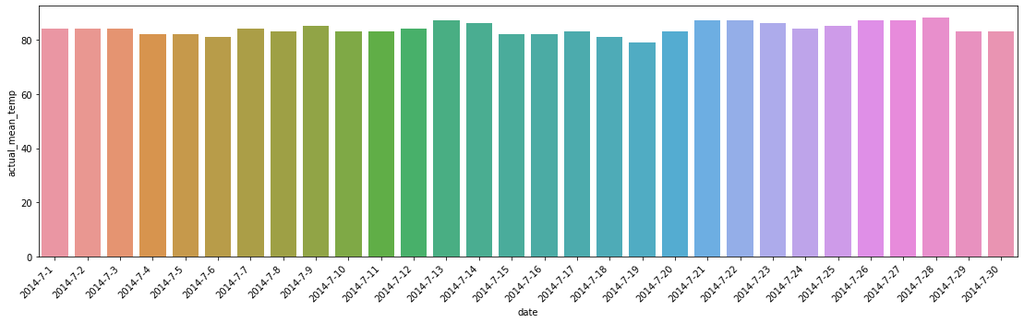

```python
plt.figure(figsize=(19, 5))
sns.barplot(x=df.index, y=df["actual_mean_temp"])

# Rotate x-axis labels and move them to the right
plt.xticks(rotation=45, ha='right')
```

## Heatmap

```python
df = pd.read_csv("data/us-weather-history/KHOU.csv")
df = df.set_index("date")

# Select first 30 dates (there are actually 365 rows, won't fit in the bar chart's x axis)
df = df.iloc[:14, :].loc[:, ["actual_mean_temp", "actual_min_temp", "actual_max_temp", "average_min_temp", "average_max_temp"]]
df
```

| date | actual_mean_temp | actual_min_temp | actual_max_temp | average_min_temp | average_max_temp |
| --- | --- | --- | --- | --- | --- |
| 2014-7-1 | 84 | 74 | 94 | 75 | 93 |
| 2014-7-2 | 84 | 74 | 94 | 75 | 93 |
| 2014-7-3 | 84 | 73 | 94 | 75 | 93 |
| 2014-7-4 | 82 | 72 | 91 | 75 | 93 |
| 2014-7-5 | 82 | 73 | 90 | 75 | 93 |
| 2014-7-6 | 81 | 72 | 89 | 75 | 93 |
| 2014-7-7 | 84 | 74 | 93 | 75 | 93 |
| 2014-7-8 | 83 | 74 | 92 | 75 | 93 |
| 2014-7-9 | 85 | 74 | 95 | 75 | 93 |
| 2014-7-10 | 83 | 73 | 93 | 75 | 93 |
| 2014-7-11 | 83 | 72 | 94 | 75 | 93 |
| 2014-7-12 | 84 | 74 | 94 | 75 | 93 |
| 2014-7-13 | 87 | 77 | 96 | 75 | 94 |
| 2014-7-14 | 86 | 76 | 96 | 75 | 94 |

Use `sns.heatmap`:

- `annot=True` to show values in each cell of the map.

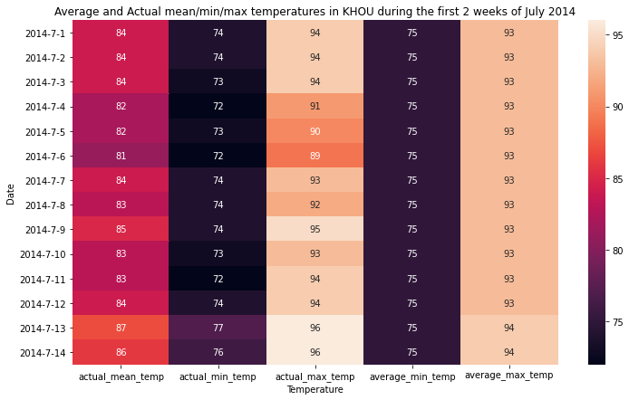

```python
plt.figure(figsize=(12,7))
plt.title("Average and Actual mean/min/max temperatures in KHOU during the first 2 weeks of July 2014")
sns.heatmap(data=df, annot=True)

# Add label for axes
plt.xlabel("Temperature")
plt.ylabel("Date")
```

# Scatter Plots

## Single-colour scatter plots + regression lines

```python
df = pd.read_csv("data/Medical Cost Personal Datasets/insurance.csv")
df = df.rename(columns={"bmi":"Body Mass Index"})
df.head()
```

|  | age | sex | Body Mass Index | children | smoker | region | charges |
| --- | --- | --- | --- | --- | --- | --- | --- |
| 0 | 19 | female | 27.900 | 0 | yes | southwest | 16884.92400 |
| 1 | 18 | male | 33.770 | 1 | no | southeast | 1725.55230 |
| 2 | 28 | male | 33.000 | 3 | no | southeast | 4449.46200 |
| 3 | 33 | male | 22.705 | 0 | no | northwest | 21984.47061 |
| 4 | 32 | male | 28.880 | 0 | no | northwest | 3866.85520 |

Use `sns.scatterplot`:

- Specify the two variables in `x` and `y` (usually `y` is the value to predict)

--> useful for detecting linear correlations between two variables e.g. the plot below shows a positive correlation between the BMI and the higher insurance costs, which makes sense since high BMI is typically associated with higher risk of chronic disease.

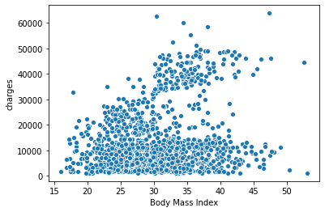

```python
sns.scatterplot(x=df["Body Mass Index"], y=df["charges"])
```

Can add a regression line (line that best fits the data) to verify the pattern observed. Do this using `sns.regplot` instead:

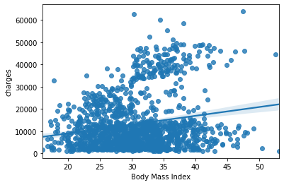

```python
sns.regplot(x=df["Body Mass Index"], y=df["charges"])
```

## Coloured scatter plots

With one colour (above), can only show relationship between 2 variables. By adding more colours, can use scatter plots to display the relationships between 3 variables.

Example: To understand how smoking affects the relationship between BMI and insurance costs, color-code the points by 'smoker', and plot the other two columns ('BMI', 'charges') on the axes:

- Use `sns.scatterplot`
- Specify the variable to colour-code with `hue` (for now convert `.to_list()` due to bug in seaborn)

--> Useful to show that smokers pay much more with increasing BMI than non-smokers.

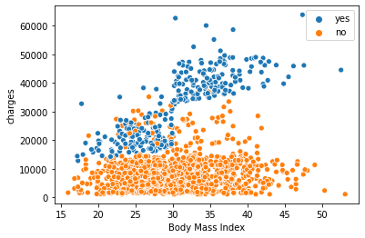

```python
sns.scatterplot(data=df, x="Body Mass Index", y="charges", hue=df["smoker"].to_list())
```

Plot 2 regression lines using `sns.lmplot`, showing that the slope is much steeper for smokers than non-smokers:

- specify dataset in `data`
- pass individual column names for `x`, `y` and `hue`

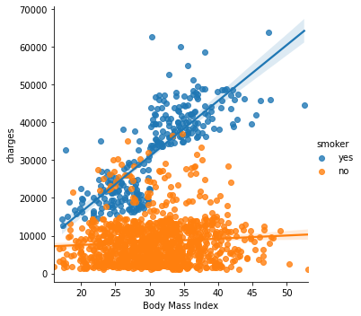

```python
sns.lmplot(data=df, x="Body Mass Index", y="charges", hue="smoker")
```

## Categorical scatter plots

Types of data:

- BMI is numerical data (can be plotted in a scatter plot to show relationship)
- smoker categorical data.

To plot categorical data like smoker, can use a swarm plot with `sns.swarmplot`:

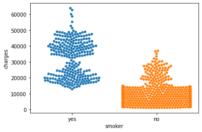

```python
sns.swarmplot(data=df, x="smoker", y="charges")
```

This shows that on average, non-smokers are charged less than smokers, and the customers who pay the most are smokers whereas the customers who pay the least are non-smokers.

# Distributions

```python
df = pd.read_csv("data/iris-species/Iris.csv")
df
```

|  | Id | SepalLengthCm | SepalWidthCm | PetalLengthCm | PetalWidthCm | Species |
| --- | --- | --- | --- | --- | --- | --- |
| 0 | 1 | 5.1 | 3.5 | 1.4 | 0.2 | Iris-setosa |
| 1 | 2 | 4.9 | 3.0 | 1.4 | 0.2 | Iris-setosa |
| 2 | 3 | 4.7 | 3.2 | 1.3 | 0.2 | Iris-setosa |
| 3 | 4 | 4.6 | 3.1 | 1.5 | 0.2 | Iris-setosa |
| 4 | 5 | 5.0 | 3.6 | 1.4 | 0.2 | Iris-setosa |
| ... | ... | ... | ... | ... | ... | ... |
| 145 | 146 | 6.7 | 3.0 | 5.2 | 2.3 | Iris-virginica |
| 146 | 147 | 6.3 | 2.5 | 5.0 | 1.9 | Iris-virginica |
| 147 | 148 | 6.5 | 3.0 | 5.2 | 2.0 | Iris-virginica |
| 148 | 149 | 6.2 | 3.4 | 5.4 | 2.3 | Iris-virginica |
| 149 | 150 | 5.9 | 3.0 | 5.1 | 1.8 | Iris-virginica |

150 rows × 6 columns

## Histograms

Histogram to show the variation of petal length in iris flowers.

Use `sns.distplot`:

- `a` is for the column to plot
- `kde`: to plot a gaussian kernel density estimate or not

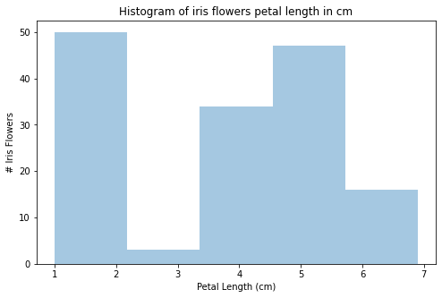

```python
plt.figure(figsize=(8, 5))
sns.distplot(a=df["PetalLengthCm"], kde=False)

# Style
plt.title("Histogram of iris flowers petal length in cm")
plt.xlabel("Petal Length (cm)")
plt.ylabel("# Iris Flowers")
```

## Density Plots (KDE)

Kernel density estimate (KDE) plots are like smoothed histograms.

Use `sns.kdeplot`:

- `data` for the column to plot
- `shaded` to colour the area under the curve

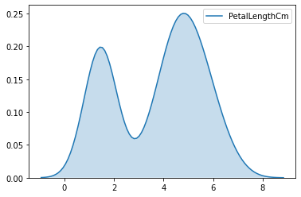

```python
sns.kdeplot(data=df["PetalLengthCm"], shade=True)
```

## 2D KDE Plots

Create a 2D KDE plot with `sns.jointplot`:

- `x` and `y` for the 2 distributions to plot
- `kind` for type of 2D distribution (can be `kde`, `scatter` or `reg`)

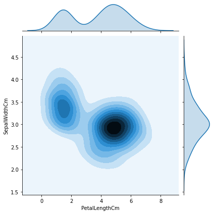

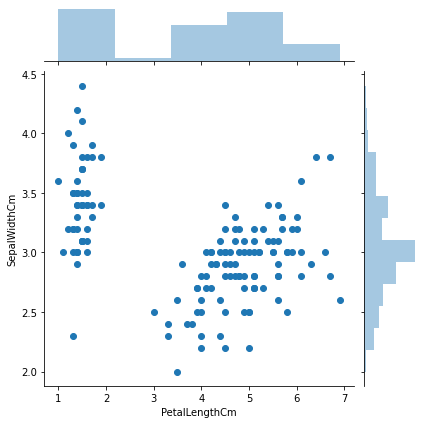

```python
sns.jointplot(x=df["PetalLengthCm"], y=df["SepalWidthCm"], kind="kde")
sns.jointplot(x=df["PetalLengthCm"], y=df["SepalWidthCm"], kind="scatter")
```

## Colour-coded distributions

Separate different types of iris flowers into unique DFs:

```python
print(f"Type of iris flowers: {df['Species'].unique()}")
df_setosa = df.loc[df["Species"] == "Iris-setosa"]
df_versicolor = df.loc[df["Species"] == "Iris-versicolor"]
df_virginica = df.loc[df["Species"] == "Iris-virginica"]
```

```
Type of iris flowers: ['Iris-setosa' 'Iris-versicolor' 'Iris-virginica']
```

Create a different histogram for each iris flower species.

Use `sns.distplot` for each species and apply a `label` to tell them apart:

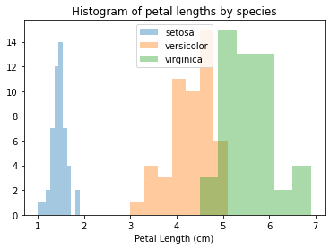

```python
sns.distplot(a=df_setosa["PetalLengthCm"], label="setosa", kde=False)
sns.distplot(a=df_versicolor["PetalLengthCm"], label="versicolor", kde=False)
sns.distplot(a=df_virginica["PetalLengthCm"], label="virginica", kde=False)

# Style
plt.title("Histogram of petal lengths by species")
plt.xlabel("Petal Length (cm)")
plt.legend()  # Force legend to appear using specified labels
```

Can do the same for KDE plots:

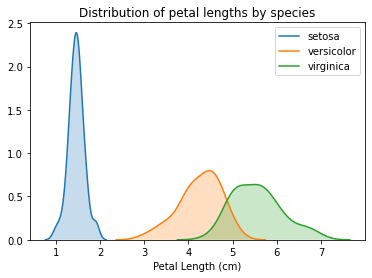

```python
sns.kdeplot(data=df_setosa["PetalLengthCm"], label="setosa", shade=True)
sns.kdeplot(data=df_versicolor["PetalLengthCm"], label="versicolor", shade=True)
sns.kdeplot(data=df_virginica["PetalLengthCm"], label="virginica", shade=True)

# Style
plt.title("Distribution of petal lengths by species")
plt.xlabel("Petal Length (cm)")
plt.legend()  # Force legend to appear using specified labels
```

# Seaborn Theme Styles

Use `sns.set_style`, choose from (1)"darkgrid", (2)"whitegrid", (3)"dark", (4)"white", and (5)"ticks"

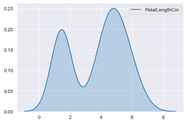

```python
sns.set_style("darkgrid")
sns.kdeplot(data=df["PetalLengthCm"], shade=True)
```

# Summary

[figure not shown]

3 categories of charts seen:

- **Trends** - A trend is defined as a pattern of change.
  - `sns.lineplot` - Line charts are best to show trends over a period of time, and multiple lines can be used to show trends in more than one group.
- **Relationship** - There are many different chart types that you can use to understand relationships between variables in your data.
  - `sns.barplot` - Bar charts are useful for comparing quantities corresponding to different groups.
  - `sns.heatmap` - Heatmaps can be used to find color-coded patterns in tables of numbers.
  - `sns.scatterplot` - Scatter plots show the relationship between two continuous variables; if color-coded, we can also show the relationship with a third categorical variable.
  - `sns.regplot` - Including a regression line in the scatter plot makes it easier to see any linear relationship between two variables.
  - `sns.lmplot` - This command is useful for drawing multiple regression lines, if the scatter plot contains multiple, color-coded groups.
  - `sns.swarmplot` - Categorical scatter plots show the relationship between a continuous variable and a categorical variable.
- **Distribution** - We visualize distributions to show the possible values that we can expect to see in a variable, along with how likely they are.
  - `sns.distplot` - Histograms show the distribution of a single numerical variable.
  - `sns.kdeplot` - KDE plots (or 2D KDE plots) show an estimated, smooth distribution of a single numerical variable (or two numerical variables).
  - `sns.jointplot` - This command is useful for simultaneously displaying a 2D KDE plot with the corresponding KDE plots for each individual variable.